# Machine Learning Project

## Background

Using devices such as Jawbone Up, Nike FuelBand, and Fitbit it is now possible to collect a large amount of data about personal activity relatively inexpensively. These type of devices are part of the quantified self movement – a group of enthusiasts who take measurements about themselves regularly to improve their health, to find patterns in their behavior, or because they are tech geeks. One thing that people regularly do is quantify how much of a particular activity they do, but they rarely quantify how well they do it. In this project, your goal will be to use data from accelerometers on the belt, forearm, arm, and dumbell of 6 participants. They were asked to perform barbell lifts correctly and incorrectly in 5 different ways. More information is available from the website here: http://groupware.les.inf.puc-rio.br/har (see the section on the Weight Lifting Exercise Dataset).

## Data

The training data for this project are available here:

https://d396qusza40orc.cloudfront.net/predmachlearn/pml-training.csv

The test data are available here:

https://d396qusza40orc.cloudfront.net/predmachlearn/pml-testing.csv

## Results

### Load and clean data

Replace missing values and #DIV/0 with NA

```r
training <- read.csv("pml-training.csv", na.strings = c("","NA","#DIV/0"))
testing <- read.csv("pml-testing.csv", na.strings = c("","NA","#DIV/0"))
```

Remove columns which do not have all data.

```r
training <- training [,colSums(is.na(training))==0]
testing <- testing [,colSums(is.na(testing))==0]
```

Remove seven first columns, which do not have relavant variables.

```r
training <- training[, -c(1:7)]
testing <- testing[, -c(1:7)]
```

### Partition data

```r
library(caret)
library(ggplot2)
```

Partition training set into training and crossvalidation

```r
set.seed(12334)
inTrain <- createDataPartition(y=training$classe, p=0.7, list=FALSE)
training_set <- training[inTrain,]
crossv_set <- training[-inTrain,]
```

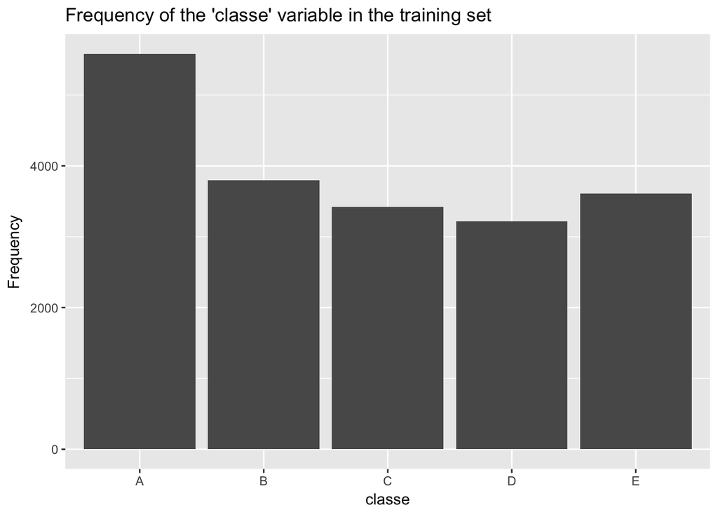

```r
qplot(training$classe, ylab="Frequency", xlab="classe", main="Frequency of the 'classe' variable in the training set")
```

### Predicting with Machine Learning algorithms

#### 1. Use of Decision tree

```r
library(rpart); library(rattle); library(rpart.plot)
```

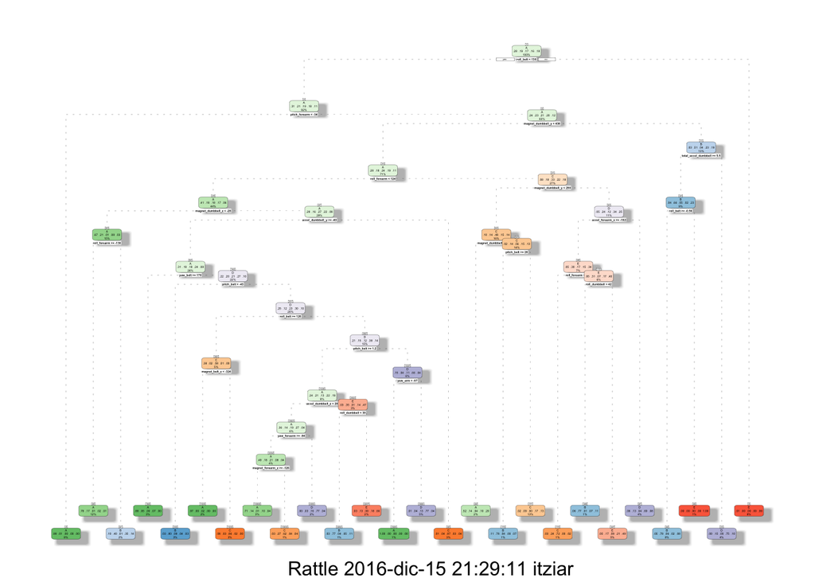

```r
fit_tree <- rpart(classe  ~. , data=training_set, method="class")
fancyRpartPlot(fit_tree)
```

Prediction with Decision tree

```r
set.seed(12334)
prediction_tree <- predict(fit_tree, crossv_set,type="class")
```

Confusion Matrix

```r
confusionMatrix(prediction_tree, crossv_set$classe)
```

```
## Confusion Matrix and Statistics
##
##           Reference
## Prediction    A    B    C    D    E
##          A 1518  178   25   56   44
##          B   67  722   62   77   96
##          C   37  111  856  133  107
##          D   25   75   56  627   55
##          E   27   53   27   71  780
##
## Overall Statistics
##
##                Accuracy : 0.7652
##                  95% CI : (0.7541, 0.7759)
##     No Information Rate : 0.2845
##     P-Value [Acc > NIR] : < 2.2e-16
##
##                   Kappa : 0.7021
##  Mcnemar's Test P-Value : < 2.2e-16
##
## Statistics by Class:
##
##                      Class: A Class: B Class: C Class: D Class: E
## Sensitivity            0.9068   0.6339   0.8343   0.6504   0.7209
## Specificity            0.9280   0.9364   0.9201   0.9571   0.9629
## Pos Pred Value         0.8336   0.7051   0.6881   0.7482   0.8142
## Neg Pred Value         0.9616   0.9142   0.9634   0.9332   0.9387
## Prevalence             0.2845   0.1935   0.1743   0.1638   0.1839
## Detection Rate         0.2579   0.1227   0.1455   0.1065   0.1325
## Detection Prevalence   0.3094   0.1740   0.2114   0.1424   0.1628
## Balanced Accuracy      0.9174   0.7851   0.8772   0.8038   0.8419
```

#### 2. Use of Random Forest

```r
library(randomForest)
```

```r
set.seed(12334)
fit_rf <- randomForest(classe  ~. , data=training_set)
```

Prediction with Random Forest

```r
prediction_rf <- predict(fit_rf, crossv_set)
```

Confusion Matrix

```r
confusionMatrix(prediction_rf, crossv_set$classe)
```

```
## Confusion Matrix and Statistics
##
##           Reference
## Prediction    A    B    C    D    E
##          A 1669    6    0    0    0
##          B    3 1130    6    0    0
##          C    0    3 1018    6    0
##          D    0    0    2  956    2
##          E    2    0    0    2 1080
##
## Overall Statistics
##
##                Accuracy : 0.9946
##                  95% CI : (0.9923, 0.9963)
##     No Information Rate : 0.2845
##     P-Value [Acc > NIR] : < 2.2e-16
##
##                   Kappa : 0.9931
##  Mcnemar's Test P-Value : NA
##
## Statistics by Class:
##
##                      Class: A Class: B Class: C Class: D Class: E
## Sensitivity            0.9970   0.9921   0.9922   0.9917   0.9982
## Specificity            0.9986   0.9981   0.9981   0.9992   0.9992
## Pos Pred Value         0.9964   0.9921   0.9912   0.9958   0.9963
## Neg Pred Value         0.9988   0.9981   0.9984   0.9984   0.9996
## Prevalence             0.2845   0.1935   0.1743   0.1638   0.1839
## Detection Rate         0.2836   0.1920   0.1730   0.1624   0.1835
## Detection Prevalence   0.2846   0.1935   0.1745   0.1631   0.1842
## Balanced Accuracy      0.9978   0.9951   0.9952   0.9954   0.9987
```

### Conclusion

Random Forest algorithm has better accuracy than Decision Trees. Accuracy for Decision Tree is 0.7652 while accuracy for Random Forest is 0.9946 Therefore, the Random Forest model is chosen. The out-of-sample error for predictions compared to the cross-validation set is approximately 0.005, and it is calculated as 1 - accuracy. With such a high accuracy, we can expect a very good classification of the 20 test samples.

## Assignment: Prediction for the test set

```r
prediction_final <- predict(fit_rf, testing)
prediction_final
```

```
##  1  2  3  4  5  6  7  8  9 10 11 12 13 14 15 16 17 18 19 20
##  B  A  B  A  A  E  D  B  A  A  B  C  B  A  E  E  A  B  B  B
## Levels: A B C D E
```